# HW10

Broderick Prows

3/18/2020

HOMEWORK 10, STAT 251 Remember to submit your R code along with the completed homework.

## Part 1

A study was done to see if taking a fish oil supplement lowered blood pressure. For the seven subjects the change in blood pressure was: 8, 12, 10, 14, 2, 0, 0. The study organizers felt it was reasonable to assume the data were conditionally iid and normally distributed. For the prior distribution of $\mu$, we have chosen a Normal distribution with a mean of 6 and a variance of 32. For the prior distribution for $\sigma^2$, we have chosen an inverse gamma with shape=3 and rate=50.

Problem Setup

```r
bp <- c(8, 12, 10, 14, 2, 0, 0)
bp_m <- 6
bp_v <- 32
bp_a <- 3
bp_b <- 50
```

Function for Gibbs Sampling

```r
library(invgamma)
gibbs_nnig <- function(m,v,a,b,data,J=10000) {
  ## set up parameters from data
  n <- length(data)
  y_bar <- mean(data)

  ## vectors to hold iterates
  mu <- numeric()
  sig2 <- numeric()

  ## insert starting values
  mu[1] <- y_bar
  sig2[1] <- var(data)

  for (j in 2:J) {

    # update mu
    m_star <- (n*v*y_bar + sig2[j-1]*m) / (n*v + sig2[j-1])
    v_star <- (v*sig2[j-1]) / (n*v + sig2[j-1])
    mu[j] <- rnorm(1,mean = m_star, sd = sqrt(v_star))

    # update sig2
    a_star <- a + n/2
    b_star <- b + sum((data-mu[j])**2)/2
    sig2[j] <- rinvgamma(1, shape = a_star, rate = b_star)

  }

  output <- list(mu,sig2)
  names(output) <- c("mu","sig2")
  return(output)

}
```

Gibbs Sampling

```r
bp_out <- gibbs_nnig(m=bp_m, v=bp_v, a=bp_a, b=bp_b,data = bp, J = 10000)
```

Examine Burn-In Period

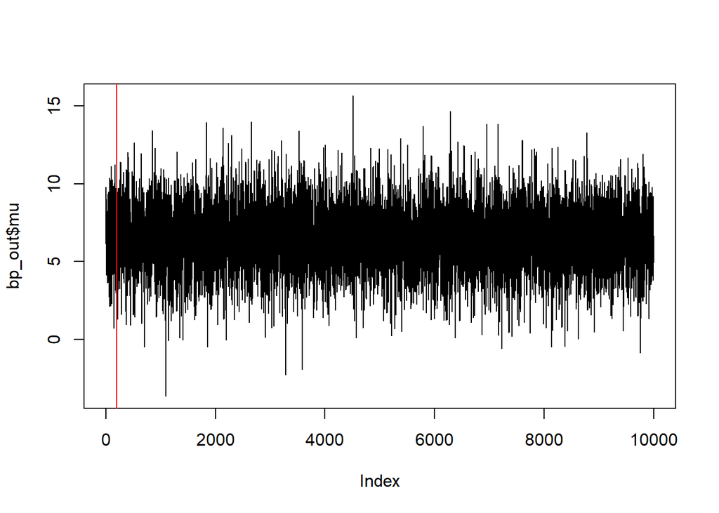

```r
plot(bp_out$mu,type='l')
abline(v=200,col='red')
```

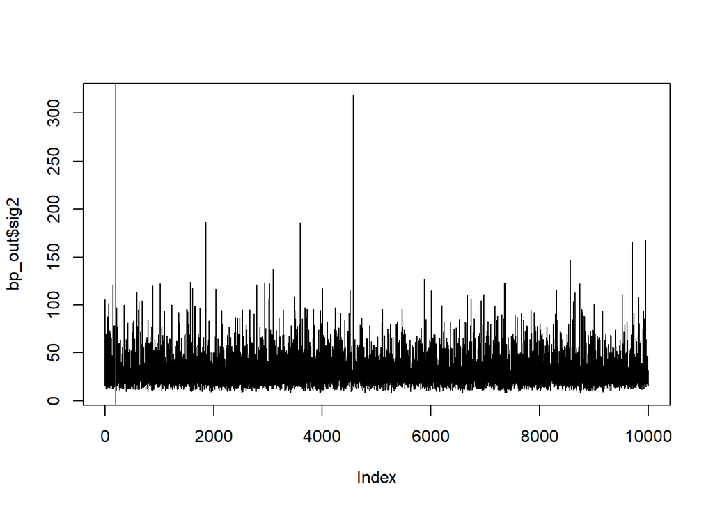

```r
plot(bp_out$sig2,type='l')
abline(v=200,col='red')
```

```r
bp_out_mu <- bp_out$mu[-c(1:200)]
bp_out_sig2 <- bp_out$sig2[-c(1:200)]
```

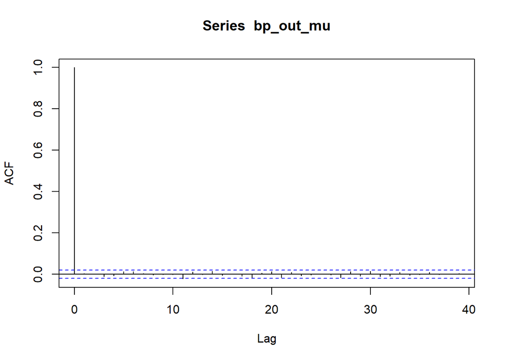

```r
acf(bp_out_mu)
```

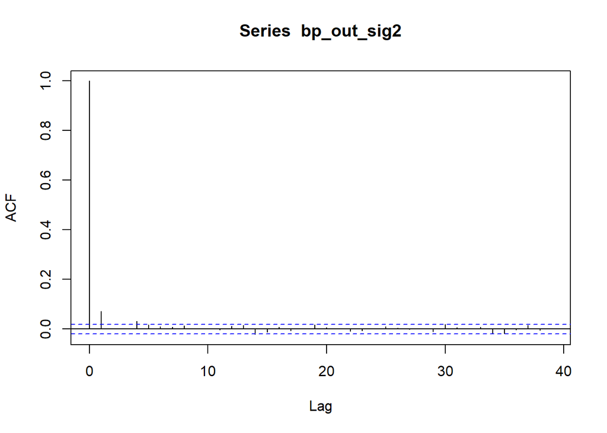

```r
acf(bp_out_sig2)
```

1. What is the posterior probability that $\mu > 0$?

```r
mean(bp_out_mu > 0)
```

```
## [1] 0.9987755
```

2. What is the posterior probability that $\sigma^2 > 30$?

```r
mean(bp_out_sig2 > 30)
```

```
## [1] 0.3889796
```

3. Plot the prior and the posterior for $\mu$ on the same graph.

```r
prior_post_plot_mu <- function(m,v,post_mu) {
  ## Address bounds
  vals <- c(m + c(-1,1)*3*sqrt(v), mean(post_mu) + c(-1,1)*3*sd(post_mu))
  lower_bound <- min(vals)
  upper_bound <- max(vals)
  mus <- seq(lower_bound,upper_bound,length.out=1001)
  ## do the plot
  plot(density(post_mu),
       xlim = c(lower_bound, upper_bound),
       col = 'black',
       type = 'l',
       main = expression(paste("Prior and Posterior of ", mu)),
       xlab = expression(mu),
       ylab = 'Density')
  lines(mus,dnorm(mus,mean=m,sd=sqrt(v)),
        col = 'gray', type = 'l')
  legend("topleft", c("Prior", "Posterior"), col = c("gray", "black"), lty = 1)
}
```

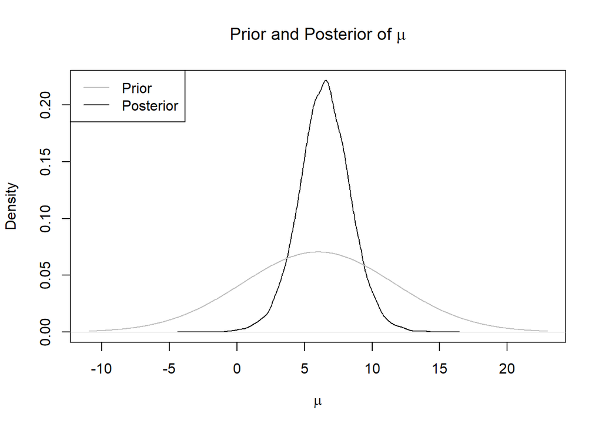

```r
prior_post_plot_mu(m=bp_m,v=bp_v,post_mu=bp_out_mu)
```

4. Plot the prior and posterior for $\sigma^2$ on the same graph.

```r
prior_post_plot_var <- function(a,b,post_sig2) {
  ## Address bounds
  x_vals <- c(quantile(post_sig2,.95), qinvgamma(p=.90,shape=a,rate=b))
  x_upper_bound <- max(x_vals)
  sig2s <- seq(0.01,x_upper_bound,length.out=1001)
  prior_density <- dinvgamma(sig2s,shape=a,rate=b)
  y_vals <- c(max(density(post_sig2)$y), max(prior_density))
  y_upper_bound <- max(y_vals)
  ## do the plot
  plot(density(post_sig2),
       xlim = c(0, x_upper_bound),
       ylim=c(0,y_upper_bound),
       col = 'black',
       type = 'l',
       main = expression(paste("Prior and Posterior of ", sigma**2)),
       xlab = expression(sigma**2),
       ylab = 'Density')
  lines(sig2s,prior_density,
        col = 'gray', type = 'l')
  legend("topright", c("Prior", "Posterior"), col = c("gray", "black"), lty = 1)
}
```

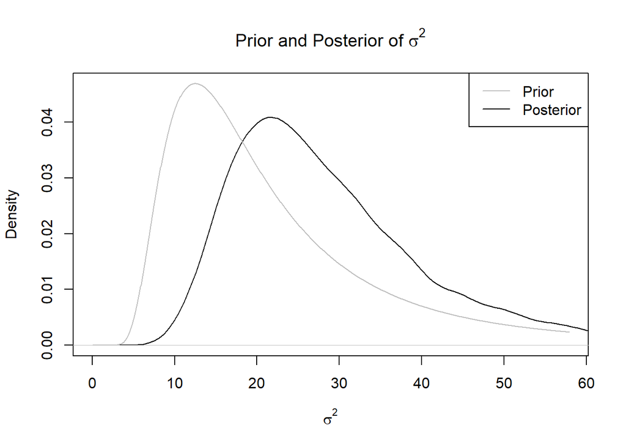

```r
prior_post_plot_var(a=bp_a,b=bp_b,post_sig2=bp_out_sig2)
```

## Part 2

Next we will consider problems 3-5 from the previous homework, but relaxing the assumption that the mean is known. As before, here is the total serum cholesterol for 9 urban residents of Guatemala: 197, 199, 214, 217, 222, 223, 227, 228, 234. It is assumed that $Y_{urban,i}|\sigma_{urban}^2 \ iid \sim N(\mu_{urban}, \sigma_{urban}^2)$, where $Y_{urban,i}$ denotes the total serum cholesterol for the ith individual in the sample of Guatemalan urban residents. The prior belief about $\sigma_{urban}^2$, the variance of the serum cholesterol of urban residents of Guatemala, is that it has an inverse gamma distribution with shape=2.1 and rate=480. The prior belief about $mu_{urban}$, the mean serum cholesterol of urban residents of Guatemala, is that it has a normal distribution with a mean of 180 and a variance of 100.

1. Get draws from the posterior distribution, and plot the posterior distribution for the mean on one graph and the posterior distribution for the variance on another graph.

```r
chol_urban <- c(197, 199, 214, 217, 222, 223, 227, 228, 234)
urban_a <- 2.1
urban_b <- 480
urban_m <- 180
urban_v <- 100
urban_out <- gibbs_nnig(m=urban_m, v=urban_v, a=urban_a, b=urban_b, data=chol_urban,J=10000)
```

Examine Burn-In Period

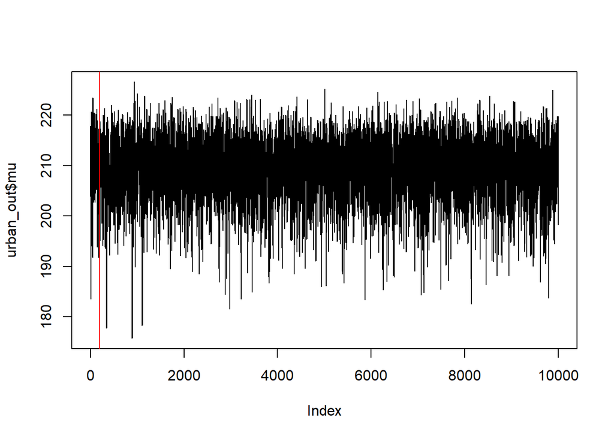

```r
plot(urban_out$mu,type='l')
abline(v=200,col='red')
```

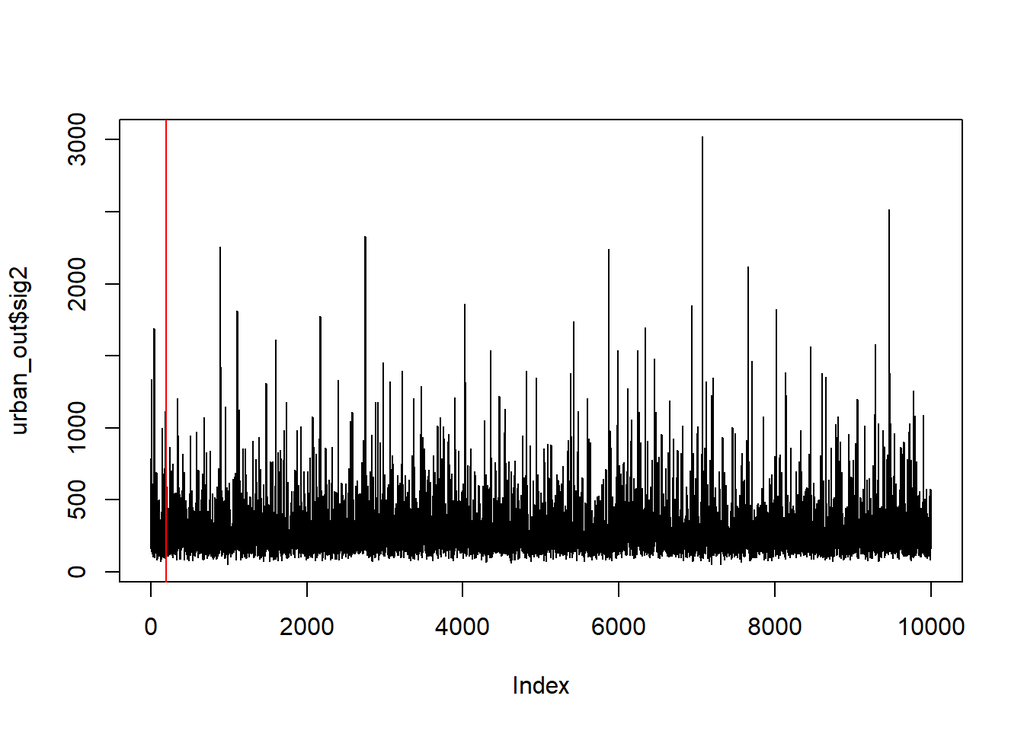

```r
plot(urban_out$sig2,type='l')
abline(v=200,col='red')
```

```r
urban_out_mu <- urban_out$mu[-c(1:200)]
urban_out_sig2 <- urban_out$sig2[-c(1:200)]
```

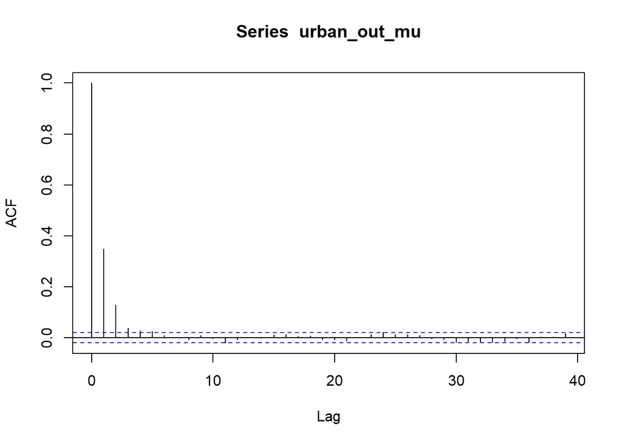

```r
acf(urban_out_mu)
```

This does not seem to be mixing all that well but it looks the same even if I throw out the first 5000 values.

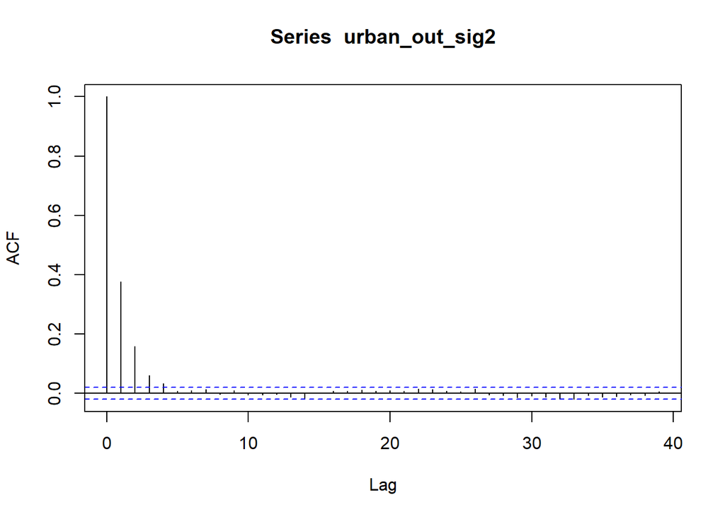

```r
acf(urban_out_sig2)
```

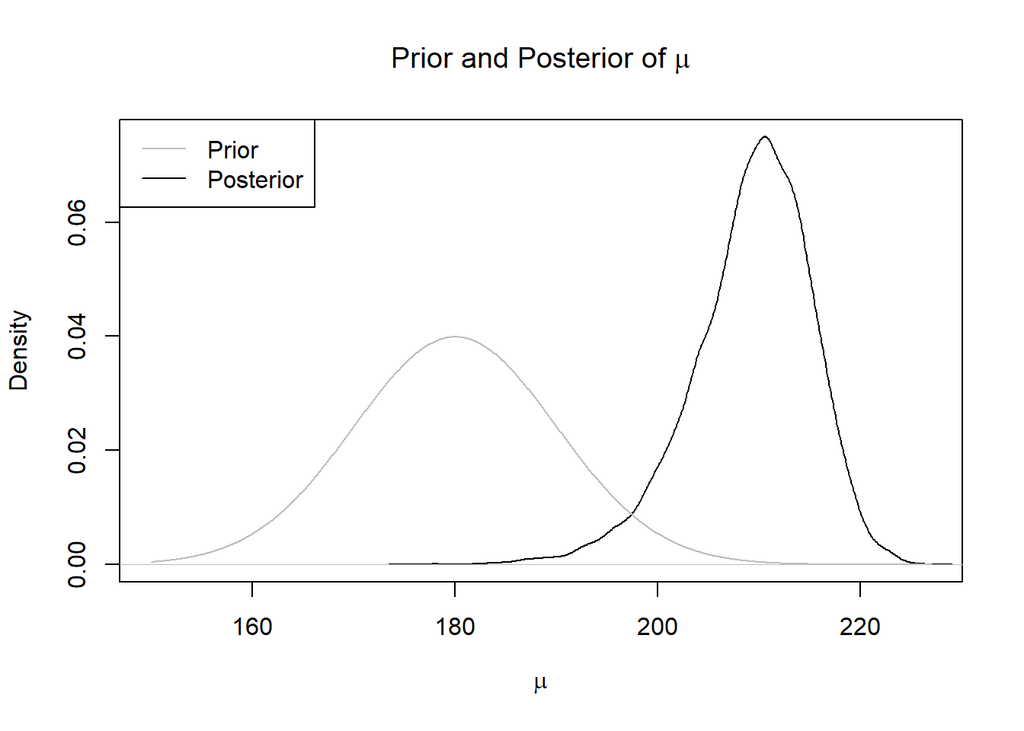

```r
prior_post_plot_mu(m=urban_m, v=urban_v, post_mu=urban_out_mu)
```

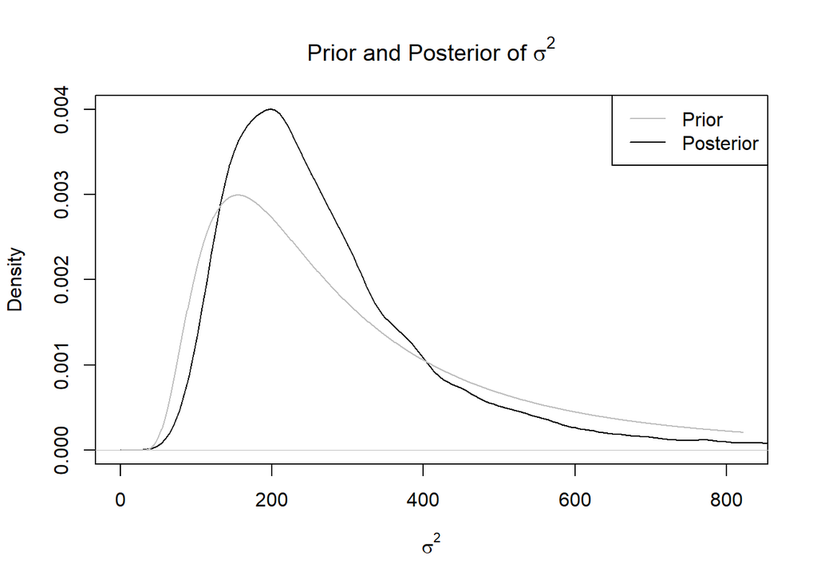

```r
prior_post_plot_var(a=urban_a, b=urban_b, post_sig2=urban_out_sig2)
```

2. What is the posterior expected value of $\sigma_{urban}^2$?

```r
mean(urban_out_sig2)
```

```
## [1] 289.0926
```

3. What is the posterior expected value of $\mu_{urban}$?

```r
mean(urban_out_mu)
```

```
## [1] 209.2239
```

4. Now, assume the prior belief about the mean is that it is normally distributed with a mean of 180 and a variance of 400. (The prior for $\sigma_{urban}^2$ is still the same.) Again get posterior draws for the mean and variance. This time plot the two posterior distributions for the mean, and include them on the same graph (the posterior for $\mu_{urban}$ from part a in gray, and the posterior for $\mu_{urban}$ from this part in black).

```r
urban_m2 <- 180
urban_v2 <- 400
urban_out2 <- gibbs_nnig(m=urban_m2, v=urban_v2, a=urban_a, b=urban_b, data=chol_urban,J=10000)
```

Examine Burn-In Period

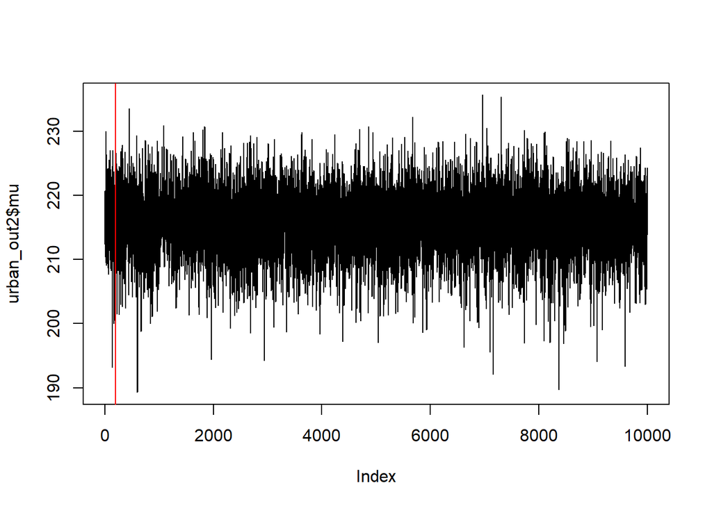

```r
plot(urban_out2$mu,type='l')
abline(v=200,col='red')
```

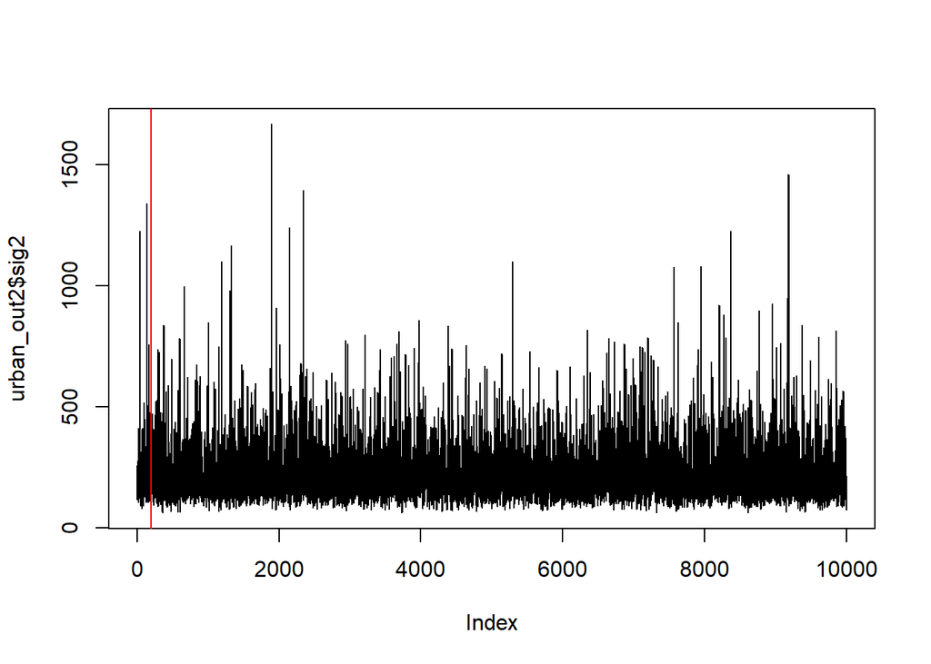

```r
plot(urban_out2$sig2,type='l')
abline(v=200,col='red')
```

```r
urban_out2_mu <- urban_out2$mu[-c(1:200)]
urban_out2_sig2 <- urban_out2$sig2[-c(1:200)]
```

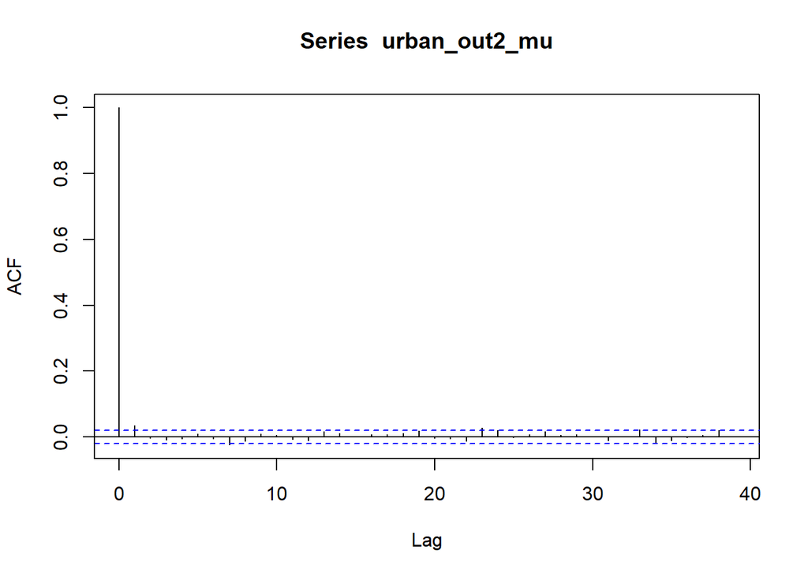

```r
acf(urban_out2_mu)
```

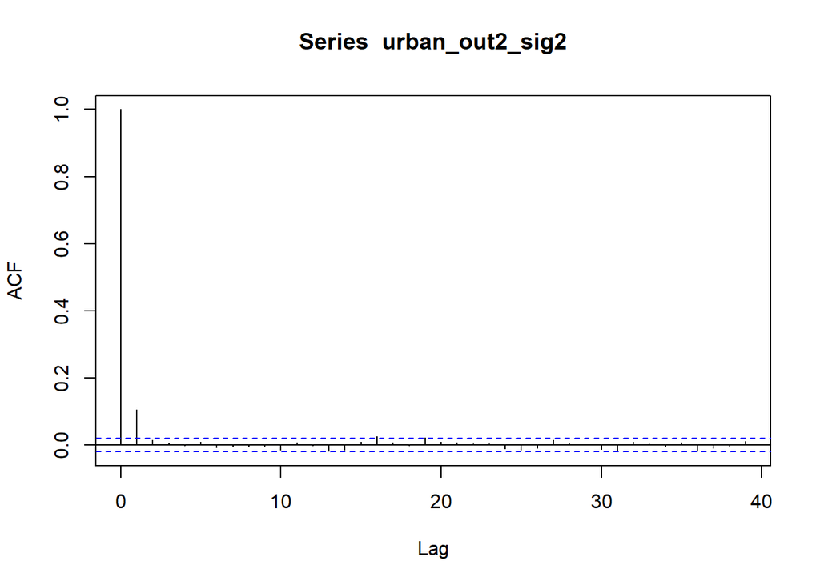

```r
acf(urban_out2_sig2)
```

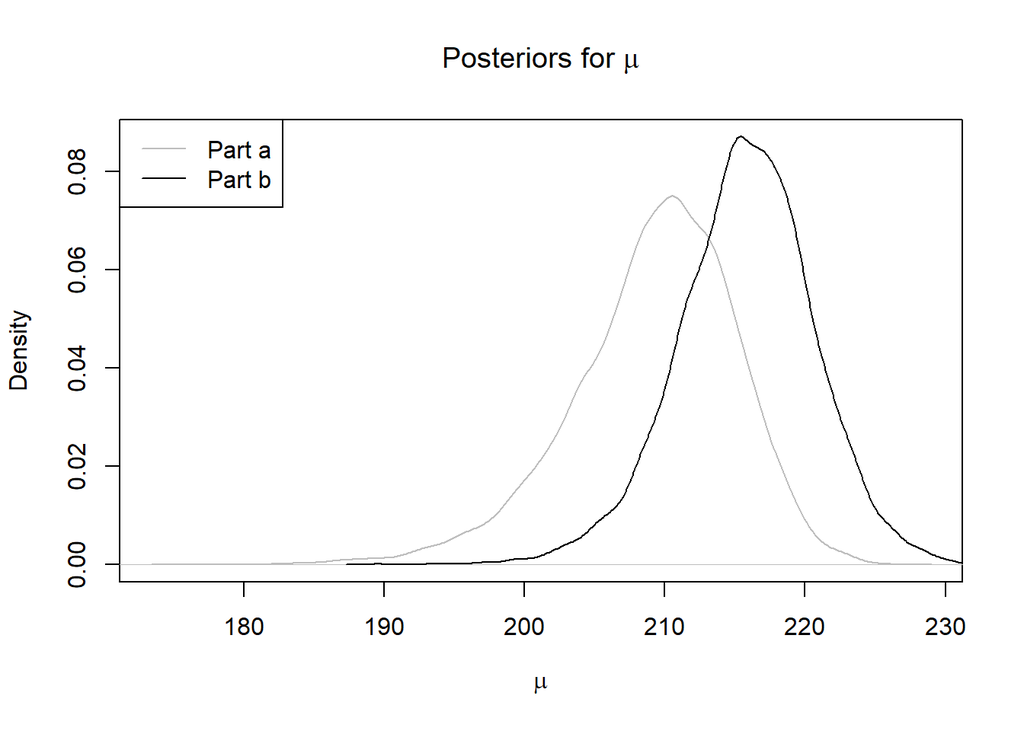

```r
y_vals <- c(density(urban_out_mu)$y, density(urban_out2_mu)$y)
y_max <- max(y_vals)
plot(density(urban_out_mu),
     col='gray',
     ylim=c(0,y_max),
     main=expression(paste("Posteriors for ",mu)),
     xlab=expression(mu),
     ylab="Density")
lines(density(urban_out2_mu))
legend("topleft", c("Part a", "Part b"), col = c("gray", "black"), lty=1)
```

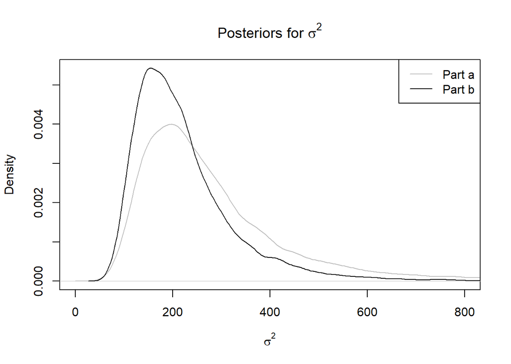

```r
y_vals <- c(density(urban_out_sig2)$y, density(urban_out2_sig2)$y)
y_max <- max(y_vals)
plot(density(urban_out_sig2),
     col='gray',
     ylim=c(0,y_max),
     xlim=c(0,800),
     main=expression(paste("Posteriors for ",sigma**2)),
     xlab=expression(sigma**2),
     ylab="Density")
lines(density(urban_out2_sig2))
legend("topright", c("Part a", "Part b"), col = c("gray", "black"), lty=1)
```

## Part 3

Here is the total serum cholesterol for 10 rural residents of Guatemala: 139, 142, 143, 144, 145, 148, 155, 162, 171, 181. The response variable (total serum cholesterol) is assumed to be conditionally iid and normally distributed. The prior belief about the serum cholesterol of rural residents of Guatemala is that the population mean should have a mean of 150 with a variance of 500. The prior for the variance is an inverse gamma with shape=3 and rate=180. Plot the posterior for the mean.

```r
rural_m <- 150
rural_v <- 500
rural_a <- 3
rural_b <- 180
chol_rural <- c(139, 142, 143, 144, 145, 148, 155, 162, 171, 181)
rural_out <- gibbs_nnig(m=rural_m, v=rural_v, a=rural_a, b=rural_b, data=chol_rural, J=10000)
```

Examine Burn-In Period

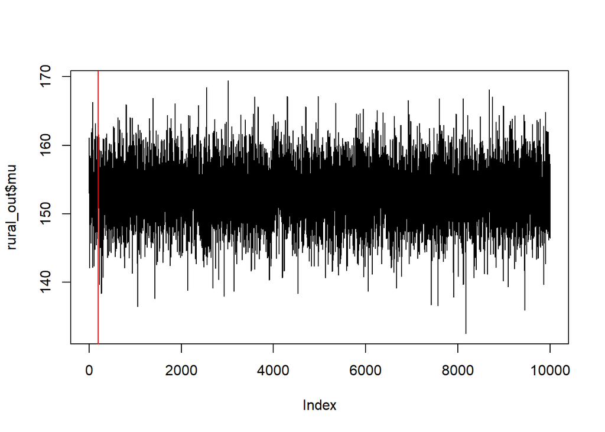

```r
plot(rural_out$mu,type='l')
abline(v=200,col='red')
```

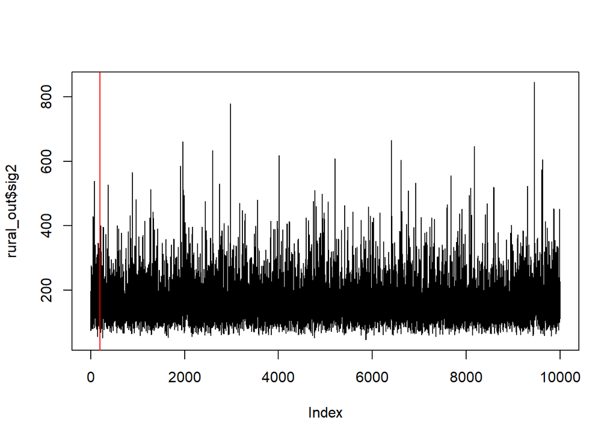

```r
plot(rural_out$sig2,type='l')
abline(v=200,col='red')
```

```r
rural_out_mu <- rural_out$mu[-c(1:200)]
rural_out_sig2 <- rural_out$sig2[-c(1:200)]
```

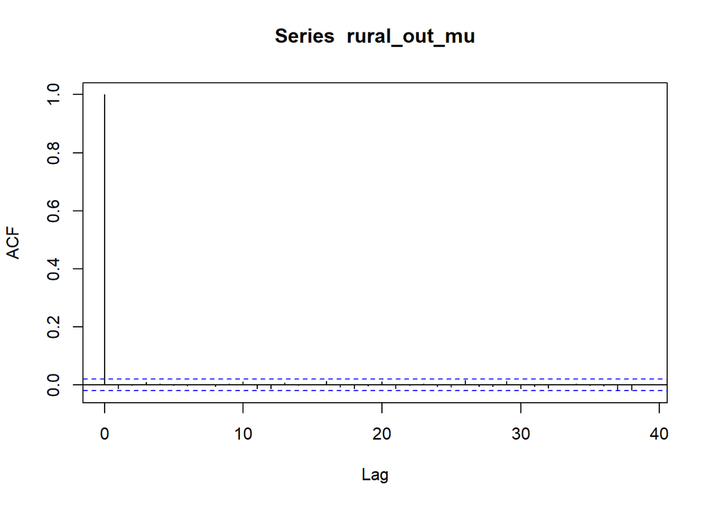

```r
acf(rural_out_mu)
```

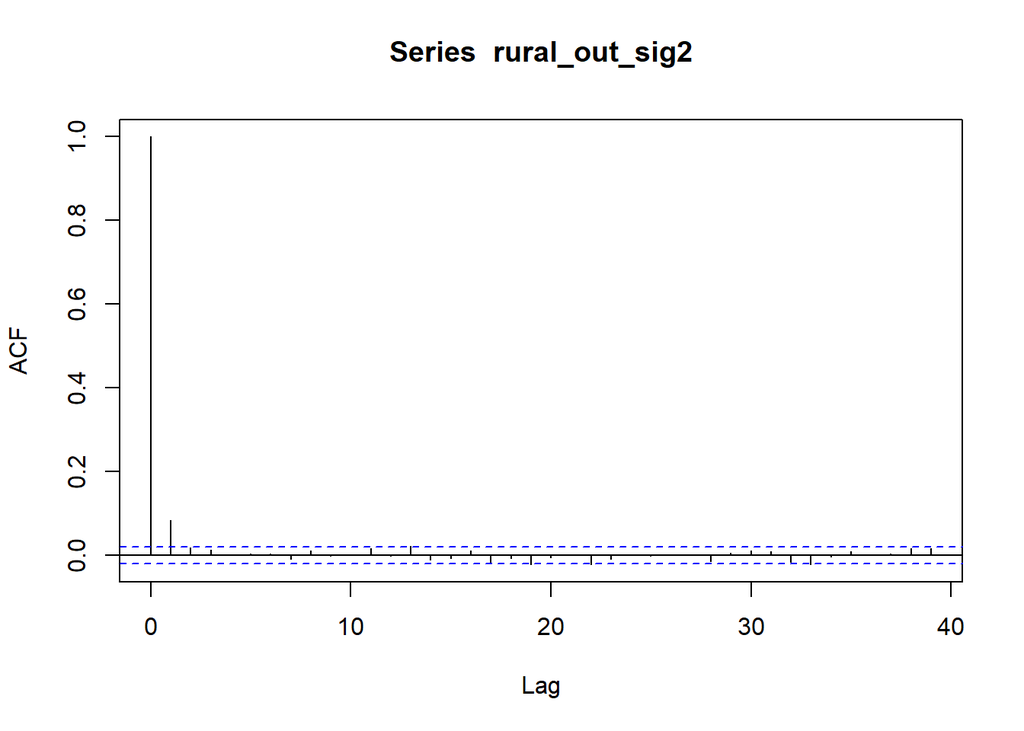

```r
acf(rural_out_sig2)
```

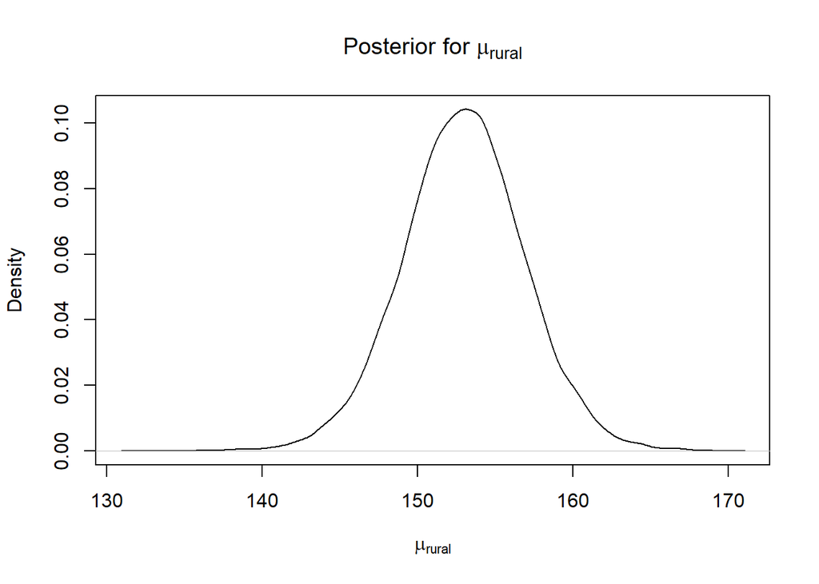

```r
plot(density(rural_out_mu),
     main = expression(paste("Posterior for ", mu["rural"])),
     xlab=expression(mu["rural"]),
     ylab="Density")
```

## Part 4

Now we consider comparing $\mu_{urban}$ to $\mu_{rural}$ and $\sigma_{urban}^2$ to $\sigma_{rural}^2$. Note the the former is akin to the independent two-sample t-test to comparing means from two populations which is regularly taught in stat 121. The former is not taught in stat 121 because the sampling distribution is beyond the scope of that course. In Bayes, inference for comparing $\sigma_{urban}^2$ to $\sigma_{rural}^2$ follows exactly as before!

1. Plot the posterior distribution of the difference in the means of the two groups: $\mu_{urban} - \mu_{rural}$. What is the 95% (posterior) credible interval for this difference? What can you conclude?

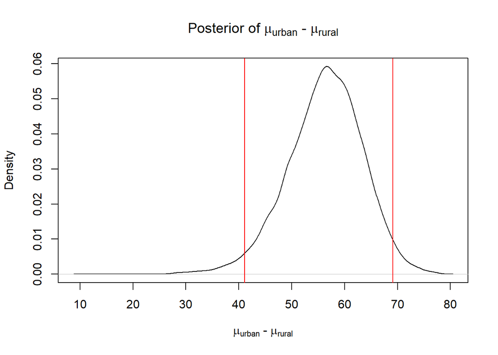

```r
diffs_mu <- urban_out_mu - rural_out_mu
interval_mu <- quantile(diffs_mu, c(0.025, 0.975))
plot(density(diffs_mu),
     main = expression(paste("Posterior of ", mu["urban"], ' - ', mu["rural"])),
     xlab = expression(paste(mu["urban"],' - ',mu["rural"])),
     ylab = "Density")
abline(v=interval_mu, col='red')
```

```r
interval_mu
```

```
##     2.5%    97.5%
## 41.13155 69.09527
```

2. Plot the posterior distribution of the ratio of variances (i.e., of $\sigma_{urban}^2 / \sigma_{rural}^2$). What is the 95% posterior credible interval for this ratio? What can you conclude?

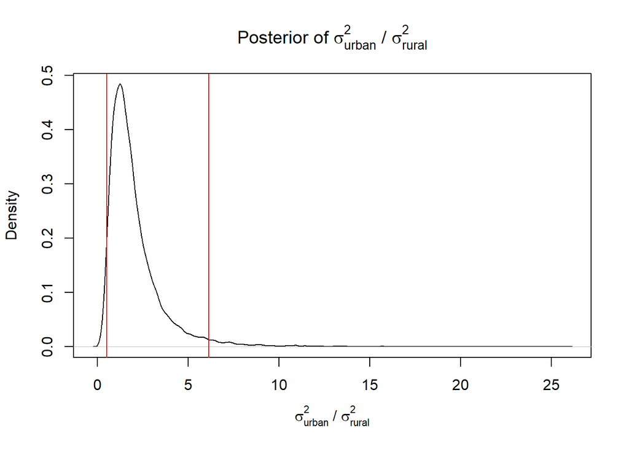

```r
ratio_sig2 <- urban_out_sig2 / rural_out_sig2
interval_sig2 <- quantile(ratio_sig2, c(0.025, 0.975))
plot(density(ratio_sig2),
     main = expression(paste("Posterior of ", sigma["urban"]**2, ' / ', sigma["rural"]**2)),
     xlab = expression(paste(sigma["urban"]**2,' / ',sigma["rural"]**2)),
     ylab = "Density")
abline(v=interval_sig2, col='red')
```

```r
interval_sig2
```

```
##      2.5%     97.5%
## 0.5148599 6.1452992
```

## Part 5

Plot the posterior predictive distribution of $Y_{urban}$ and the posterior predictive distribution of $Y_{rural}$ on the same graph. (This of course requires a legend be included in your plot to distinguish one from the other.). Obtain an interval for difference in prediction of the urban group relative to the rural. How does this interval compare to that one found in part 4a?

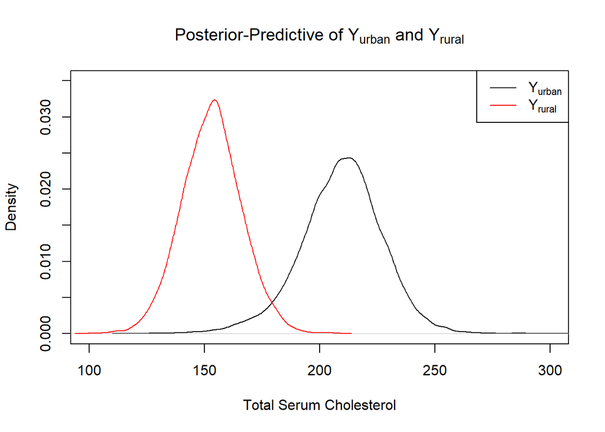

```r
y_urban_pred <- rnorm(length(urban_out_mu), urban_out_mu, sqrt(urban_out_sig2))
y_rural_pred <- rnorm(length(rural_out_mu), rural_out_mu, sqrt(rural_out_sig2))
plot(density(y_urban_pred),
     main = expression(paste("Posterior-Predictive of ", Y[urban], " and ", Y[rural])),
     xlab = "Total Serum Cholesterol", ylab = "Density", col = "black",
     xlim = c(100,300), ylim = c(0,0.035))
lines(density(y_rural_pred), col = 'red')
legend("topright", c(expression(Y[urban]), expression(Y[rural])), col = c('black', 'red'), lty=1)
```

This interval is wider than the one in part 4a because it is measuring predicted y’s rather than a posterior of $\mu$. This distribution takes into account the posterior variance for each distribution instead of just the variance associated to $\mu$.

```r
diffs_y <- y_urban_pred - y_rural_pred
quantile(diffs_y, c(0.025, 0.975))
```

```
##     2.5%    97.5%
## 10.10990 99.10993
```